# Impulsive Online Fashion Purchase Study

Tasnim Talha

# Introduction

This research investigates the drivers of impulsive online fashion buying among Generation Z consumers in Dhaka, Bangladesh, by examining the relationship between external social pressures and internal psychological states. The study finds that while peer influence and social status create background pressure, personality traits serve as the primary internal drivers that shape an individual’s behavioral traits, such as the tendency to act without forethought or seek emotional gratification.

## Aims & Objectives

### **Aim**

To critically investigate the determinants of impulsive online fashion buying behavior among Generation Z consumers in Dhaka by analyzing the collective influence of external social pressures (peer influence and perceived social status) and internal personality traits, while examining how demographic factors and shopping platforms moderate these behaviors.

### **Primary Objectives**

1. To examine the impact of peer influence and perceived social status on the frequency of impulsive online fashion purchases.
2. To evaluate the role of specific personality traits (such as high impulsivity and hedonic motives) in driving unplanned fashion buying behavior.

### **Secondary Objectives**

3. To analyze the inter-relationship between peer influence and social status, specifically determining if peer pressure intensifies the need for status signaling.
4. To assess the variations in impulsive buying behavior based on situational factors, including choice of social commerce platform and preferred payment methods.
5. To compare impulsive buying tendencies across different demographic groups, focusing on gender differences and the impact of monthly financial allowance.
6. To determine the relationship between high impulsivity and the psychological outcome of post-purchase regret.

## Setting up the Environment & Importing the Dataset

First, we import the necessary libraries for **Exploratory Data Analysis (EDA)** and **hypothesis testing**.

```r
# importing the necessary libraries
library(tidyverse)
library(readxl)
library(psych)
library(car)
# printing a confirmation message
message("The libraries have been imported successfully.")
```

```
## The libraries have been imported successfully.
```

Now, we import the dataframe and take a look at the first few rows of the **raw data**.

```r
# importing the raw dataframe and inspecting the first few rows
df_raw <- read_excel(path = "data/survey_response.xlsx", sheet = "raw_data")
head(df_raw)
```

```
## # A tibble: 6 × 27
##   Timestamp           `What is your age range?` `What is your gender?`
##   <dttm>              <chr>                     <chr>
## 1 2026-01-11 01:53:53 23–27                     Female
## 2 2026-01-11 08:39:49 23–27                     Male
## 3 2026-01-11 09:33:21 23–27                     Female
## 4 2026-01-11 09:54:58 23–27                     Male
## 5 2026-01-11 11:41:22 23–27                     Male
## 6 2026-01-11 13:34:23 23–27                     Female
## # ℹ 24 more variables: `What is your personal monthly allowance/income?` <chr>,
## #   `What is your preferred method of payment for any sort of purchase—be it fashion item or non-fashion item?` <chr>,
## #   `How frequently do you buy fashion items online?` <chr>,
## #   `Which platform do you use the most for online fashion shopping?` <chr>,
## #   `I discuss fashion purchases with friends or family before buying.` <dbl>,
## #   `Seeing my friends post about fashion brands increases my urge to buy.` <dbl>,
## #   `Seeing influencers cover certain fashion brands increases my urge to buy that item.` <dbl>, …
```

The raw dataframe has longer questions and have some redundant columns that will be unnecessary for our analysis. So, we load the **clean dataframe** sheet which replaces all the longer questions with q1, q2,… and so on. The clean dataframe sheet also drops the redundant columns as well. Finally, the last three questions—q23, q24, and q25—are numerically coded so that they can be inserted into the models.

```r
# importing the clean dataframe and inspecting the first few rows
df <- read_excel(path = "data/survey_response.xlsx", sheet = "clean_data")
head(df)
```

```
## # A tibble: 6 × 26
##   Timestamp           q1    q2     q3        q4    q5    q6       q7    q8    q9
##   <dttm>              <chr> <chr>  <chr>     <chr> <chr> <chr> <dbl> <dbl> <dbl>
## 1 2026-01-11 01:53:53 23–27 Female 5,000–10… Mobi… 2–3 … Inst…     4     4     5
## 2 2026-01-11 08:39:49 23–27 Male   Below 5,… Cash… Once… Inst…     2     1     1
## 3 2026-01-11 09:33:21 23–27 Female Above 20… Mobi… Rare… Bran…     4     3     2
## 4 2026-01-11 09:54:58 23–27 Male   5,000–10… Cash… Rare… Face…     3     1     1
## 5 2026-01-11 11:41:22 23–27 Male   Above 20… Cash… Once… Face…     3     4     4
## 6 2026-01-11 13:34:23 23–27 Female Below 5,… Cash… Once… Bran…     4     2     2
## # ℹ 16 more variables: q10 <dbl>, q11 <dbl>, q12 <dbl>, q13 <dbl>, q14 <dbl>,
## #   q15 <dbl>, q16 <dbl>, q17 <dbl>, q18 <dbl>, q19 <dbl>, q20 <dbl>,
## #   q21 <dbl>, q22 <dbl>, q23 <dbl>, q24 <dbl>, q25 <dbl>
```

# Data Preparation

## Factorizing the Appropriate Columns

First, there are some columns where order matters. For those column, we convert them into factors.

```r
df <- df |>
  mutate(
    across(c(q2, q4, q6), as.factor),
    q1 = factor(
      x = q1,
      levels = c("18–22", "23–27", "28 and above"),
      ordered = TRUE
      ),
    q3 = factor(
      x = q3,
      levels = c("Below 5,000", "5,000–10,000", "10,000–15,000", "15,000–20,000", "Above 20,000"),
      ordered = TRUE
      ),
    q5 = factor(
      x = q5,
      levels = c("Rarely", "Once a couple months", "Once a month", "2–3 times a month", "Once a week or more"),
      ordered = TRUE
      ),
    q23_label = factor(
      x = q23,
      levels = c(1:5),
      labels = c("Never", "Rarely", "Sometimes", "Often", "Very Often"),
      ordered = TRUE
      ),
    q24_label = factor(
      x = q24,
      levels = c(1, 3, 5),
      labels = c("No, never", "Yes, a few times", "Yes, many times"),
      ordered = TRUE
      ),
    q25_label = factor(
      x = q25,
      levels = c(1, 3, 5),
      labels = c("No", "Maybe", "Yes"),
      ordered = TRUE
      )
  )
```

We create some **composite indices** of the rows in our dataframe across the **three** independent variables—peer influence, perceived social status, and personality traits—and **one** dependent variable of the study.

## Creating Composite Indices

```r
# creating composite indices
df <- df %>%
  mutate(peer_influence_index = rowMeans(across(q7:q11), na.rm = TRUE)) %>%
  mutate(social_status_index = rowMeans(across(q12:q15), na.rm = TRUE)) %>%
  mutate(personality_index = rowMeans(across(q16:q22), na.rm = TRUE)) %>%
  mutate(dependent_variable_index = rowMeans(across(q23:q24), na.rm = TRUE))

# displaying the composite indices column
head(
  df %>%
    select(peer_influence_index, social_status_index, personality_index, dependent_variable_index)
)
```

```
## # A tibble: 6 × 4
##   peer_influence_index social_status_index personality_index
##                  <dbl>               <dbl>             <dbl>
## 1                  4.2                4                 3.57
## 2                  1.2                1.75              1.14
## 3                  2.2                2.75              2.14
## 4                  1.8                1.75              2.57
## 5                  3.6                3.5               3.14
## 6                  3.4                3                 3.29
## # ℹ 1 more variable: dependent_variable_index <dbl>
```

## Calculating the Cronbach’s Alphas

Finally, we calculate the **Cronbach’s alpha** to assess the internal consistency of the multi-item constructs. **Cronbach’s alpha** (𝛼) is a coefficient of internal consistency or reliability used to measure how closely related a set of items (e.g., Likert scale questions) are as a group.

```r
# for Peer Influence
alpha_peer_influence <- alpha(df[, c("q7","q8","q9","q10","q11")])

# for Perceived Social Status
alpha_social_status <- alpha(df[, c("q12","q13","q14","q15")])

# for Personality Traits
alpha_personality_traits <- alpha(df[, c("q16","q17","q18","q19","q20", "q21", "q22")])

# displaying the results
alpha_peer_influence
```

```
##
## Reliability analysis
## Call: alpha(x = df[, c("q7", "q8", "q9", "q10", "q11")])
##
##   raw_alpha std.alpha G6(smc) average_r S/N   ase mean   sd median_r
##       0.65      0.65    0.62      0.27 1.8 0.044    3 0.84     0.28
##
##     95% confidence boundaries
##          lower alpha upper
## Feldt     0.55  0.65  0.73
## Duhachek  0.56  0.65  0.73
##
##  Reliability if an item is dropped:
##     raw_alpha std.alpha G6(smc) average_r S/N alpha se  var.r med.r
## q7       0.66      0.66    0.61      0.33 2.0    0.044 0.0070  0.29
## q8       0.54      0.54    0.49      0.23 1.2    0.059 0.0096  0.28
## q9       0.59      0.59    0.53      0.26 1.4    0.053 0.0080  0.29
## q10      0.56      0.56    0.52      0.24 1.3    0.057 0.0214  0.23
## q11      0.61      0.61    0.58      0.28 1.6    0.050 0.0205  0.30
##
##  Item statistics
##       n raw.r std.r r.cor r.drop mean  sd
## q7  160  0.53  0.53  0.32   0.25  3.4 1.3
## q8  160  0.72  0.72  0.64   0.50  3.0 1.3
## q9  160  0.64  0.66  0.55   0.42  2.5 1.2
## q10 160  0.71  0.70  0.58   0.48  3.1 1.4
## q11 160  0.62  0.62  0.44   0.36  2.8 1.4
##
## Non missing response frequency for each item
##        1    2    3    4    5 miss
## q7  0.12 0.14 0.21 0.29 0.23    0
## q8  0.17 0.24 0.17 0.29 0.14    0
## q9  0.24 0.28 0.26 0.16 0.06    0
## q10 0.19 0.14 0.19 0.31 0.16    0
## q11 0.24 0.21 0.16 0.28 0.11    0
```

```r
alpha_social_status
```

```
##
## Reliability analysis
## Call: alpha(x = df[, c("q12", "q13", "q14", "q15")])
##
##   raw_alpha std.alpha G6(smc) average_r S/N   ase mean   sd median_r
##       0.69      0.69    0.65      0.35 2.2 0.037  2.8 0.86     0.33
##
##     95% confidence boundaries
##          lower alpha upper
## Feldt     0.61  0.69  0.77
## Duhachek  0.62  0.69  0.77
##
##  Reliability if an item is dropped:
##     raw_alpha std.alpha G6(smc) average_r S/N alpha se  var.r med.r
## q12      0.59      0.58    0.52      0.31 1.4    0.052 0.0396  0.25
## q13      0.59      0.58    0.52      0.32 1.4    0.052 0.0334  0.28
## q14      0.57      0.57    0.48      0.31 1.3    0.056 0.0053  0.28
## q15      0.73      0.73    0.66      0.48 2.8    0.037 0.0063  0.51
##
##  Item statistics
##       n raw.r std.r r.cor r.drop mean   sd
## q12 160  0.78  0.76  0.64   0.54  2.8 1.32
## q13 160  0.78  0.76  0.65   0.53  2.2 1.31
## q14 160  0.78  0.77  0.69   0.58  2.0 1.16
## q15 160  0.52  0.59  0.34   0.29  4.2 0.93
##
## Non missing response frequency for each item
##        1    2    3    4    5 miss
## q12 0.20 0.24 0.21 0.23 0.12    0
## q13 0.46 0.21 0.12 0.16 0.06    0
## q14 0.50 0.21 0.15 0.12 0.03    0
## q15 0.01 0.05 0.12 0.36 0.45    0
```

```r
alpha_personality_traits
```

```
##
## Reliability analysis
## Call: alpha(x = df[, c("q16", "q17", "q18", "q19", "q20", "q21", "q22")])
##
##   raw_alpha std.alpha G6(smc) average_r S/N   ase mean  sd median_r
##        0.8      0.79    0.79      0.35 3.8 0.024  2.8 0.9     0.35
##
##     95% confidence boundaries
##          lower alpha upper
## Feldt     0.74   0.8  0.84
## Duhachek  0.75   0.8  0.84
##
##  Reliability if an item is dropped:
##     raw_alpha std.alpha G6(smc) average_r S/N alpha se var.r med.r
## q16      0.76      0.76    0.76      0.34 3.1    0.028 0.023  0.30
## q17      0.77      0.77    0.76      0.35 3.3    0.028 0.019  0.33
## q18      0.75      0.74    0.73      0.32 2.9    0.031 0.013  0.33
## q19      0.76      0.75    0.74      0.34 3.1    0.030 0.012  0.33
## q20      0.75      0.75    0.74      0.33 2.9    0.030 0.014  0.33
## q21      0.79      0.79    0.78      0.39 3.8    0.025 0.018  0.41
## q22      0.80      0.79    0.78      0.39 3.9    0.024 0.017  0.41
##
##  Item statistics
##       n raw.r std.r r.cor r.drop mean  sd
## q16 160  0.69  0.70  0.62   0.56  3.1 1.3
## q17 160  0.66  0.66  0.58   0.52  2.6 1.3
## q18 160  0.77  0.76  0.73   0.64  3.1 1.5
## q19 160  0.73  0.71  0.68   0.60  3.3 1.4
## q20 160  0.75  0.74  0.70   0.62  3.0 1.4
## q21 160  0.53  0.56  0.43   0.38  1.8 1.2
## q22 160  0.53  0.54  0.42   0.36  2.4 1.3
##
## Non missing response frequency for each item
##        1    2    3    4    5 miss
## q16 0.17 0.13 0.26 0.26 0.17    0
## q17 0.24 0.28 0.19 0.21 0.08    0
## q18 0.23 0.15 0.17 0.22 0.22    0
## q19 0.19 0.09 0.21 0.30 0.21    0
## q20 0.22 0.16 0.16 0.29 0.17    0
## q21 0.59 0.22 0.07 0.07 0.05    0
## q22 0.32 0.26 0.18 0.16 0.09    0
```

Now, we can enter the **EDA** phase of the project.

# Exploratory Data Analysis (EDA)

Now, we do some exploratory data analysis on the dataset to understand the relationships between the features and the target variable. We will use various visualization techniques such as histograms, box plots, scatter plots, and correlation matrices to analyze the data.

## Demographics & Basic Behavior

### Age & Gender Distribution

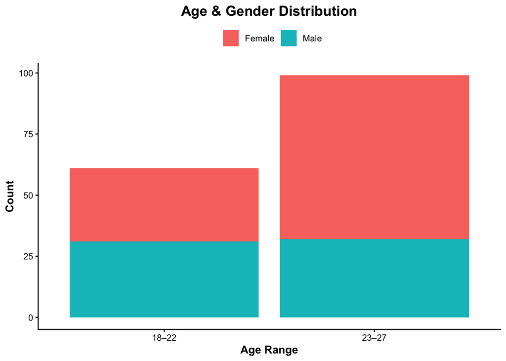

```r
# creating a stacked bar chart to observe the age vs gender distribution
ggplot(data = df, aes(x = q1, fill = q2)) +
  geom_bar(position = "stack") +
  labs(
    title = "Age & Gender Distribution",
    x = "Age Range",
    y = "Count",
    fill = ""
  ) +
  theme_classic() +
  theme(
    plot.title = element_text(hjust = 0.5, face = "bold", size = 14),
    axis.title.x = element_text(face = "bold"),
    axis.title.y = element_text(face = "bold"),
    legend.position = "top"
  )
```

**Key Insights**

- The sample skews female (97 vs 63) and toward the 23–27 band (99 vs 61 in 18–22).
- The imbalance is concentrated in 23–27, where females (67) more than double males (32); the 18–22 band is nearly even (30 vs 31).
- The **28 and above** group is totally absent (0 respondent), so age is really a two-category variable in practice.

### Income vs. Online Shopping Frequency

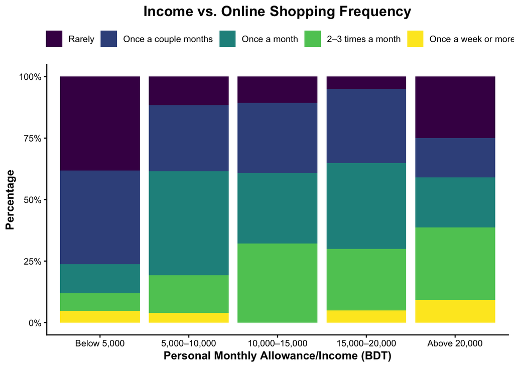

```r
# creating a stacked bar chart to observe the income vs online shopping frequency
ggplot(data = df, aes(x = q3, fill = q5)) +
  geom_bar(position = "fill") +
  scale_y_continuous(labels = scales::percent) +
  labs(
    title = "Income vs. Online Shopping Frequency",
    x = "Personal Monthly Allowance/Income (BDT)",
    y = "Percentage",
    fill = ""
  ) +
  theme_classic() +
  theme(
    plot.title = element_text(hjust = 0.5, face = "bold", size = 14),
    axis.title.x = element_text(face = "bold"),
    axis.title.y = element_text(face = "bold"),
    legend.position = "top"
  )
```

**Key Insights**

- Lower-income respondents shop least often: in **Below 5,000**, 76% shop **Rarely** or **Once a couple months**.
- Purchase frequency rises with income—the mid and upper bands shift toward **Once a month** and more.
- **Once a week or more** is rare across every income band, so heavy shoppers are uncommon regardless of income.

## Platform & Shopping Behavior

### Most Used Fashion Purchase Platform & Preferred Payment Method Distribution

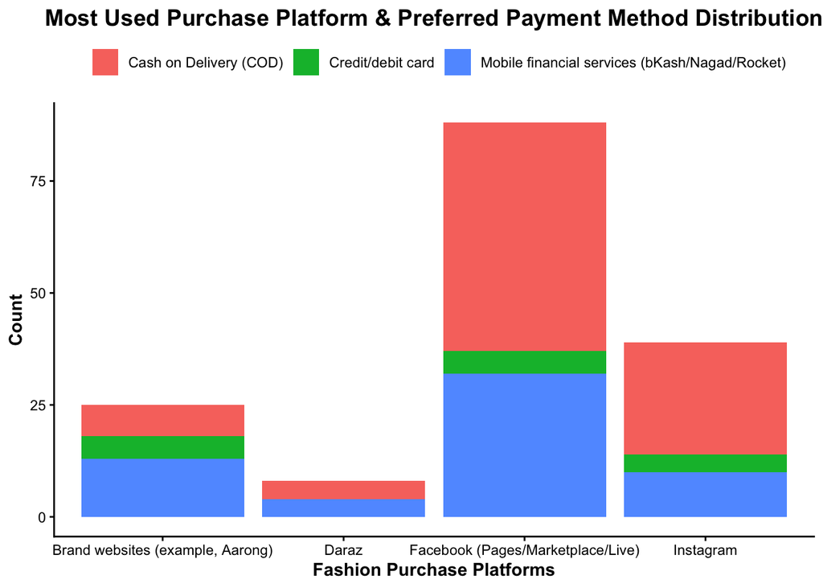

```r
# creating a stacked bar chart to observe the fashion purchase platform vs online preferred payment method distribution
ggplot(data = df, aes(x = q6, fill = q4)) +
  geom_bar(position = "stack") +
  labs(
    title = "Most Used Purchase Platform & Preferred Payment Method Distribution",
    x = "Fashion Purchase Platforms",
    y = "Count",
    fill = ""
  ) +
  theme_classic() +
  theme(
    plot.title = element_text(hjust = 0.5, face = "bold", size = 14),
    axis.title.x = element_text(face = "bold"),
    axis.title.y = element_text(face = "bold"),
    legend.position = "top"
  )
```

**Key Insights**

- **Facebook** is the dominant platform (88 of 160), followed by **Instagram** (39); **Daraz** (8) and **brand websites** (25) are minor.
- **Cash on Delivery** is the most common payment method overall, and especially on Facebook (51 of 88 ≈ 58%).
- Interestingly, brand-website buyers lean toward mobile financial services (13 of 25) rather than COD—a different pattern from the social platforms.

### Shopping Frequency

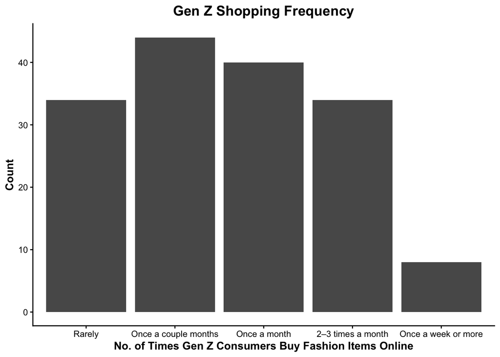

```r
# creating a barchart of how often people actually shops
ggplot(data = df, aes(x = q5)) +
  geom_bar() +
  labs(
    title = "Gen Z Shopping Frequency",
    x = "No. of Times Gen Z Consumers Buy Fashion Items Online",
    y = "Count"
  ) +
  theme_classic() +
  theme(
    plot.title = element_text(hjust = 0.5, face = "bold", size = 14),
    axis.title.x = element_text(face = "bold"),
    axis.title.y = element_text(face = "bold")
  )
```

**Key Insights**

The modal category is **Once a couple months** (44), and only 8 respondents shop weekly—the distribution is concentrated in low-to-moderate frequency.

## Peer Pressure

### Peer Pressure Score Distribution

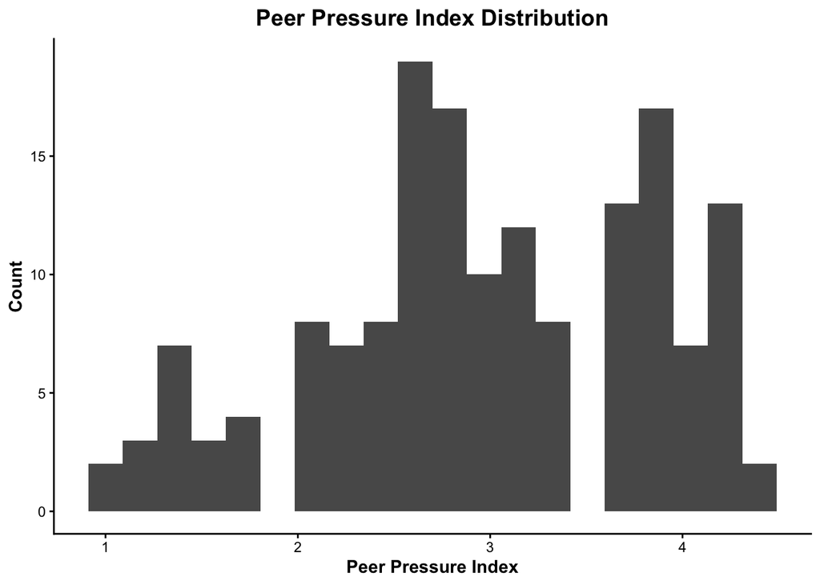

```r
# creating a histogram of the peer pressure index column created earlier
ggplot(data = df, aes(x = peer_influence_index)) +
  geom_histogram(bins = 20) +
  labs(title = "Peer Pressure Index Distribution", x = "Peer Pressure Index", y = "Count") +
  theme_classic() +
  theme(
    plot.title = element_text(hjust = 0.5, face = "bold", size = 14),
    axis.title.x = element_text(face = "bold"),
    axis.title.y = element_text(face = "bold")
  )
```

**Key Insights**

- Centered near the scale midpoint (mean 2.96, median 3.0, SD 0.84).
- Notably, no respondent scores above 4.4 despite a 1–5 scale—the top of the range is empty, suggesting few strongly peer-driven consumers.

### Peer Pressure by Demographics

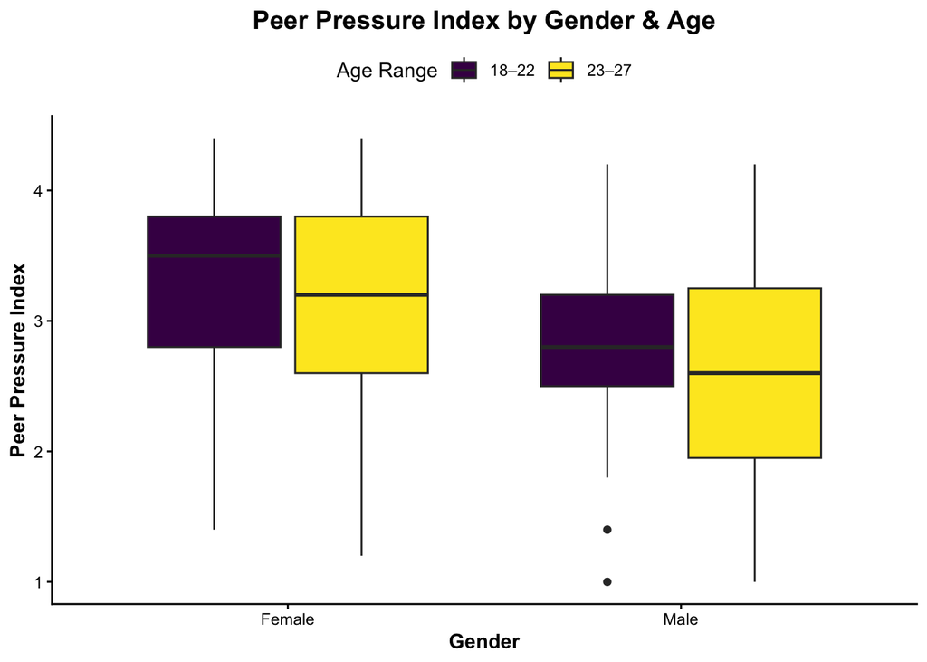

```r
# peer pressure index by gender & age
ggplot(data = df,aes(x = q2, y = peer_influence_index, fill = q1)) +
  geom_boxplot() +
  labs(
    title = "Peer Pressure Index by Gender & Age",
    x = "Gender",
    y = "Peer Pressure Index",
    fill = "Age Range"
  ) +
  theme_classic() +
  theme(
    plot.title = element_text(hjust = 0.5, face = "bold", size = 14),
    axis.title.x = element_text(face = "bold"),
    axis.title.y = element_text(face = "bold"),
    legend.position = "top"
  )
```

**Key Insights**

- Females report higher peer influence than males at both ages (medians ~3.2–3.5 vs ~2.6–2.8).
- The gender gap is larger than the age gap, hinting gender matters more than age here.

### Peer Pressure vs. Regret

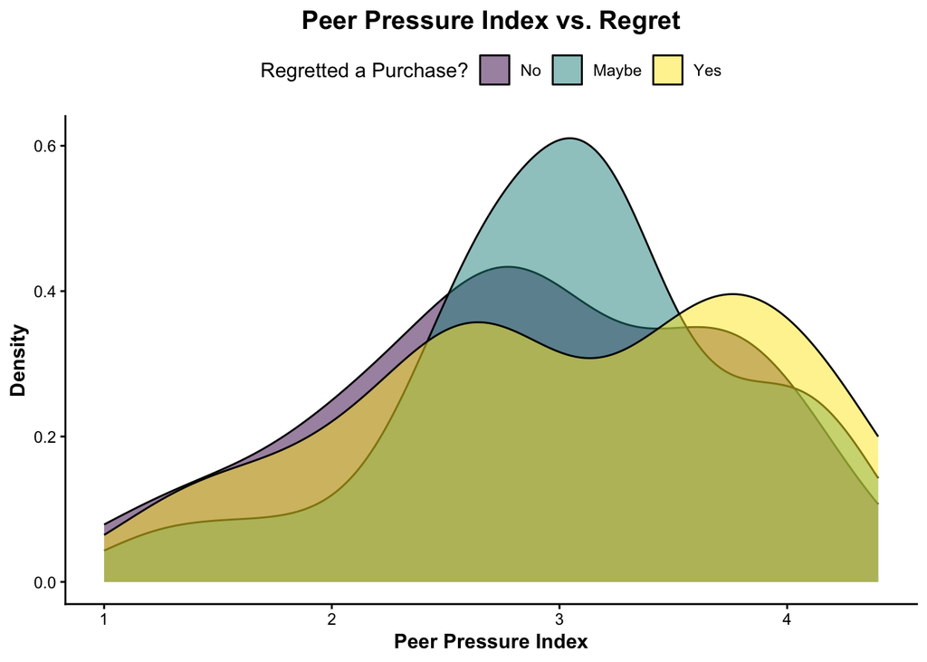

```r
# displaying the relationship between purchase regret and peer pressure index
ggplot(data = df, aes(
  x = peer_influence_index,
  fill = q25_label
)) +
  geom_density(alpha = 0.5) +
  labs(
    title = "Peer Pressure Index vs. Regret",
    x = "Peer Pressure Index",
    y = "Density",
    fill = "Regretted a Purchase?"
  ) +
  theme_classic() +
  theme(
    plot.title = element_text(hjust = 0.5, face = "bold", size = 14),
    axis.title.x = element_text(face = "bold"),
    axis.title.y = element_text(face = "bold"),
    legend.position = "top"
  )
```

### Peer Pressure vs. Unnecessary Purchase

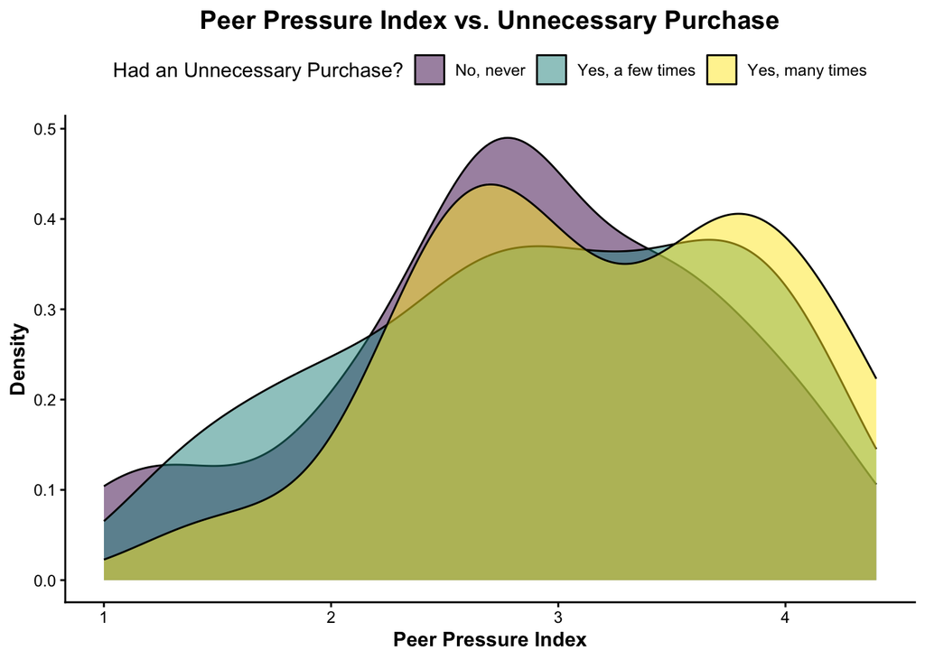

```r
# displaying the relationship between unnecessary purchase and peer pressure index
ggplot(data = df, aes(
  x = peer_influence_index,
  fill = q24_label
  )) +
  geom_density(alpha = 0.5) +
  labs(
    title = "Peer Pressure Index vs. Unnecessary Purchase",
    x = "Peer Pressure Index",
    y = "Density",
    fill = "Had an Unnecessary Purchase?"
    ) +
  theme_classic() +
  theme(
    plot.title = element_text(hjust = 0.5, face = "bold", size = 14),
    axis.title.x = element_text(face = "bold"),
    axis.title.y = element_text(face = "bold"),
    legend.position = "top"
  )
```

**Key Insights**

Peer influence shows little separation by either outcome—regret and unnecessary purchase.

### Peer Pressure vs. Social Status

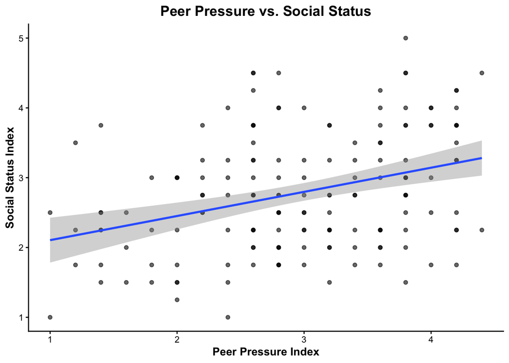

```r
# peer pressure index vs social status index
ggplot(df, aes(x = peer_influence_index, y = social_status_index)) +
  geom_point(alpha = 0.6) +
  geom_smooth(method = "lm") +
  labs(
    title = "Peer Pressure vs. Social Status",
    x = "Peer Pressure Index",
    y = "Social Status Index"
  ) +
  theme_classic() +
  theme(
    plot.title = element_text(hjust = 0.5, face = "bold", size = 14),
    axis.title.x = element_text(face = "bold"),
    axis.title.y = element_text(face = "bold")
  )
```

**Key Insights**

A weak-to-moderate positive trend (r ≈ 0.34) suggests that respondents who feel more peer pressure also tend to perceive higher social status pressure, but the relationship is far from deterministic.

### Peer Pressure vs. Personality Traits

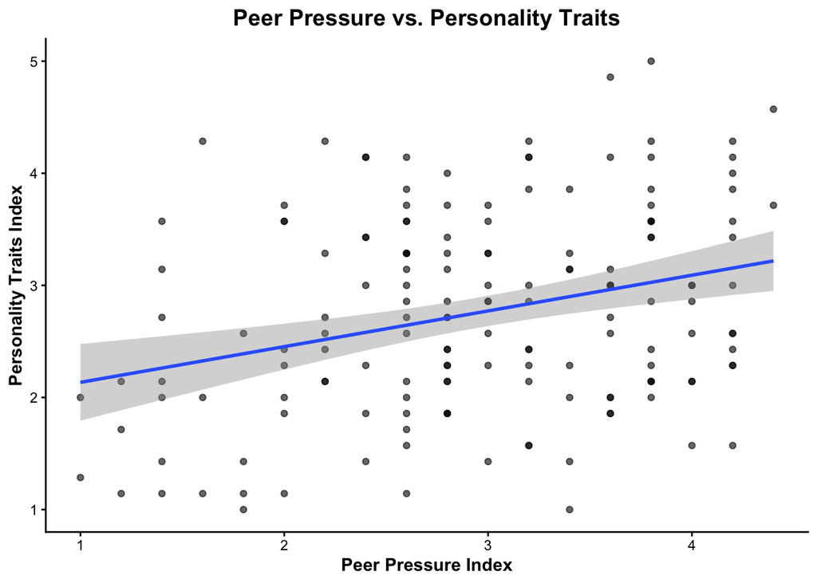

```r
# peer pressure index vs personality index
ggplot(df, aes(x = peer_influence_index, y = personality_index)) +
  geom_point(alpha = 0.6) +
  geom_smooth(method = "lm") +
  labs(
    title = "Peer Pressure vs. Personality Traits",
    x = "Peer Pressure Index",
    y = "Personality Traits Index"
  ) +
  theme_classic() +
  theme(
    plot.title = element_text(hjust = 0.5, face = "bold", size = 14),
    axis.title.x = element_text(face = "bold"),
    axis.title.y = element_text(face = "bold")
  )
```

**Key Insights**

A similarly weak positive association (r ≈ 0.30)—peer influence and personality share some common ground but are largely independent constructs.

### Peer Pressure vs. Dependent Variable

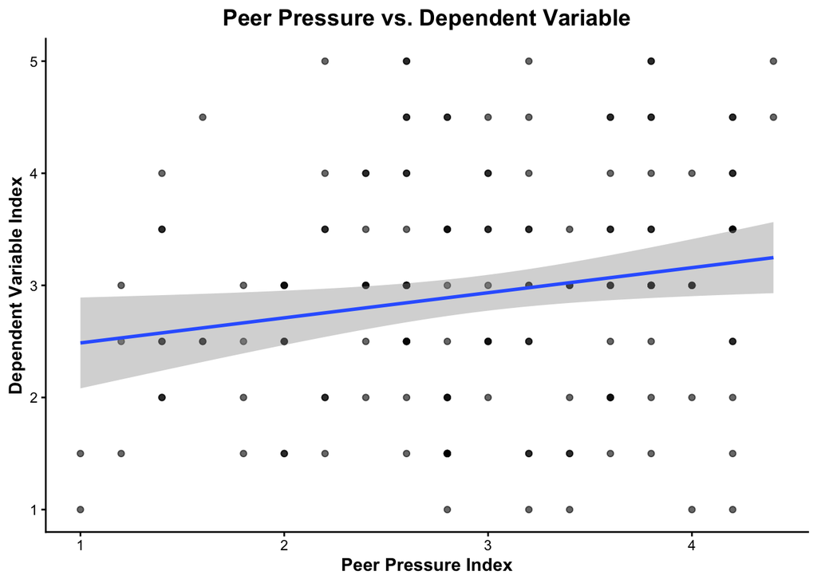

```r
# creating a scatterplot of the peer pressure index and the dependent variable index
ggplot(data = df, aes(x = peer_influence_index, y = dependent_variable_index)) +
  geom_point(alpha = 0.6) +
  geom_smooth(method = "lm") +
  labs(
    title = "Peer Pressure vs. Dependent Variable",
    x = "Peer Pressure Index",
    y = "Dependent Variable Index"
  ) +
  theme_classic() +
  theme(
    plot.title = element_text(hjust = 0.5, face = "bold", size = 14),
    axis.title.x = element_text(face = "bold"),
    axis.title.y = element_text(face = "bold")
  )
```

**Key Insights**

- Peer influence correlates weakly-to-moderately with social status (r = 0.34) and personality (r = 0.30).
- Its correlation with the dependent variable is the weakest of all predictors (r = 0.18)—an early hint that peer influence may not drive impulsive buying directly.

## Perceived Social Status

### Social Status Score Distribution

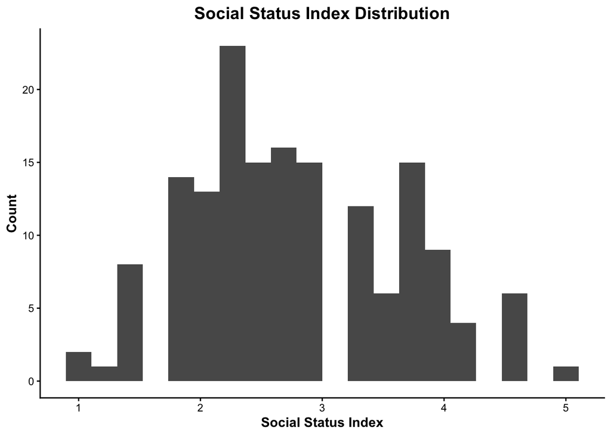

```r
# creating a histogram of the social status index column created earlier
ggplot(data = df, aes(x = social_status_index)) +
  geom_histogram(bins = 20) +
  labs(title = "Social Status Index Distribution", x = "Social Status Index", y = "Count") +
  theme_classic() +
  theme(
    plot.title = element_text(hjust = 0.5, face = "bold", size = 14),
    axis.title.x = element_text(face = "bold"),
    axis.title.y = element_text(face = "bold")
  )
```

**Key Insights**

Roughly central and symmetric (mean 2.78, median 2.75, SD 0.86), spanning the full 1–5 range with no unusual features.

### Social Status by Demographics

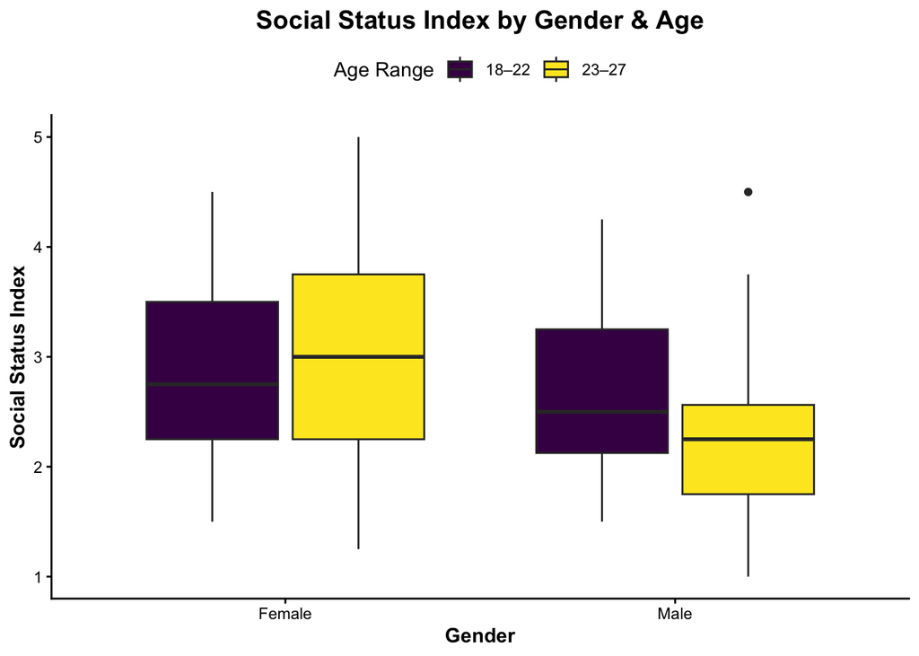

```r
# social status index by gender & age
ggplot(data = df,aes(x = q2, y = social_status_index, fill = q1)) +
  geom_boxplot() +
  labs(
    title = "Social Status Index by Gender & Age",
    x = "Gender",
    y = "Social Status Index",
    fill = "Age Range"
  ) +
  theme_classic() +
  theme(
    plot.title = element_text(hjust = 0.5, face = "bold", size = 14),
    axis.title.x = element_text(face = "bold"),
    axis.title.y = element_text(face = "bold"),
    legend.position = "top"
  )
```

**Key Insights**

- Females again score somewhat higher than males (medians ~2.75–3.0 vs 2.25–2.5).
- Differences are modest and the boxes overlap, so the gender gap is smaller here than for peer influence.

### Social Status vs. Regret

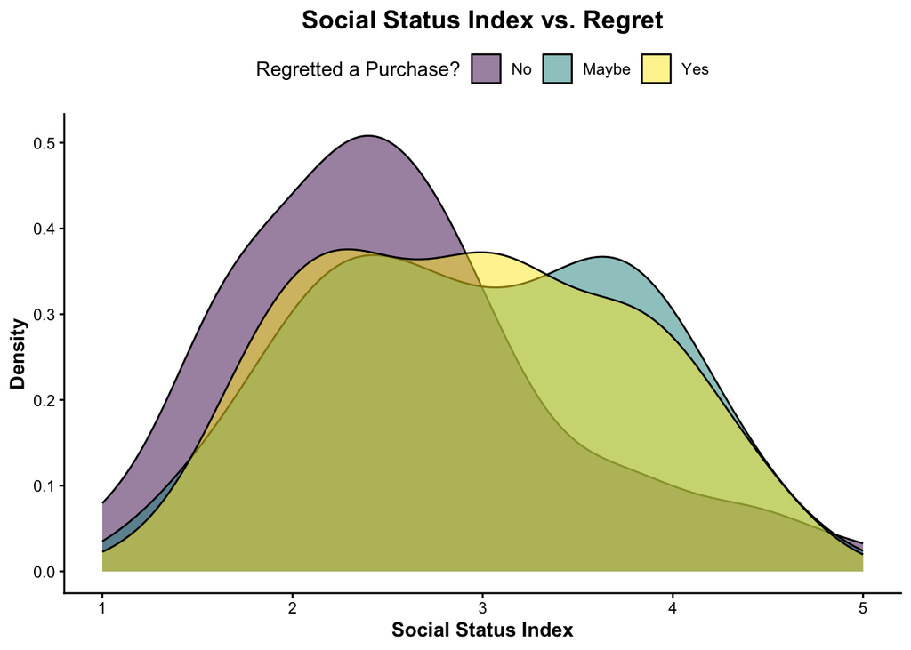

```r
# displaying the relationship between purchase regret and social status index
ggplot(data = df, aes(
  x = social_status_index,
  fill = q25_label
  )) +
  geom_density(alpha = 0.5) +
  labs(
    title = "Social Status Index vs. Regret",
    x = "Social Status Index",
    y = "Density",
    fill = "Regretted a Purchase?"
  ) +
  theme_classic() +
  theme(
    plot.title = element_text(hjust = 0.5, face = "bold", size = 14),
    axis.title.x = element_text(face = "bold"),
    axis.title.y = element_text(face = "bold"),
    legend.position = "top"
  )
```

### Social Status vs. Unnecessary Purchase

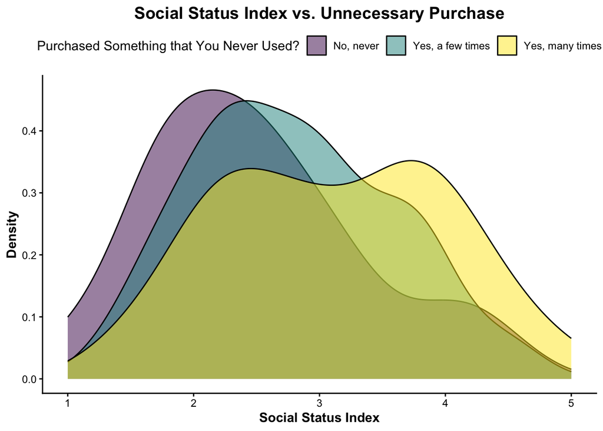

```r
# displaying the relationship between social status and unnecessary purchases
ggplot(data = df, aes(
  x = social_status_index,
  fill = q24_label
  )) +
  geom_density(alpha = 0.5) +
  labs(
    title = "Social Status Index vs. Unnecessary Purchase",
    x = "Social Status Index",
    y = "Density",
    fill = "Purchased Something that You Never Used?"
    ) +
  theme_classic() +
  theme(
    plot.title = element_text(hjust = 0.5, face = "bold", size = 14),
    axis.title.x = element_text(face = "bold"),
    axis.title.y = element_text(face = "bold"),
    legend.position = "top"
  )
```

### Social Status vs. Personality Traits

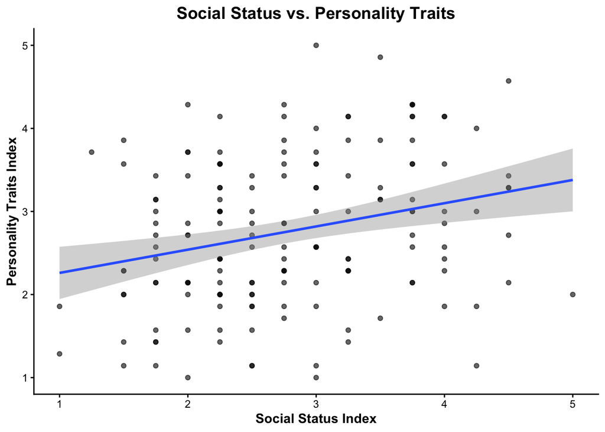

```r
# social status index vs. personality index
ggplot(df, aes(x = social_status_index, y = personality_index)) +
  geom_point(alpha = 0.6) +
  geom_smooth(method = "lm") +
  labs(
    title = "Social Status vs. Personality Traits",
    x = "Social Status Index",
    y = "Personality Traits Index"
  ) +
  theme_classic() +
  theme(
    plot.title = element_text(hjust = 0.5, face = "bold", size = 14),
    axis.title.x = element_text(face = "bold"),
    axis.title.y = element_text(face = "bold")
  )
```

**Key Insights**

A weak positive association (r ≈ 0.27) between social status and personality—the two constructs share some overlap but measure distinct dimensions.

### Social Status vs. Dependent Variable

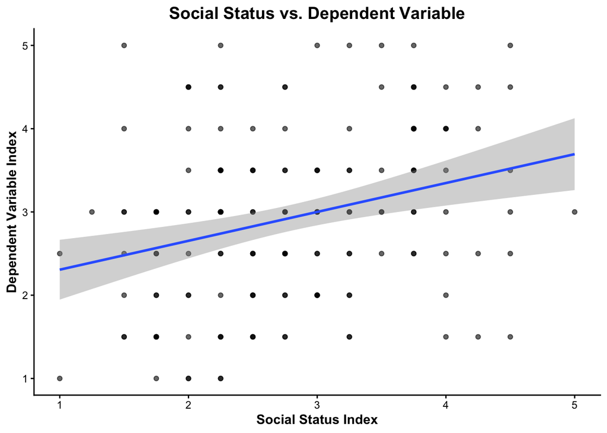

```r
# creating a scatterplot of the social status index and the dependent variable index
ggplot(data = df, aes(x = social_status_index, y = dependent_variable_index)) +
  geom_point(alpha = 0.6) +
  geom_smooth(method = "lm") +
  labs(
    title = "Social Status vs. Dependent Variable",
    x = "Social Status Index",
    y = "Dependent Variable Index"
  ) +
  theme_classic() +
  theme(
    plot.title = element_text(hjust = 0.5, face = "bold", size = 14),
    axis.title.x = element_text(face = "bold"),
    axis.title.y = element_text(face = "bold")
  )
```

**Key Insights**

Social status correlates moderately with the dependent variable (r ≈ 0.29)—stronger than peer influence but well below personality’s standout association.

## Personality Traits

### Personality Score Distribution

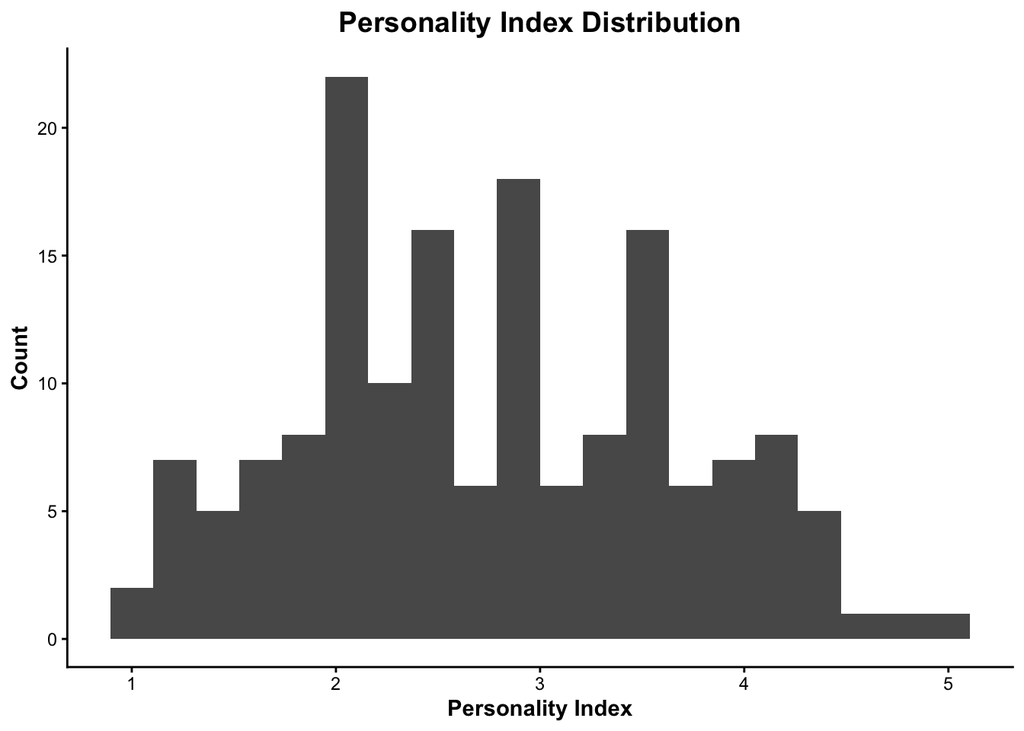

```r
# creating a histogram of personality index distribution
ggplot(data = df, aes(x = personality_index)) +
  geom_histogram(bins = 20) +
  labs(title = "Personality Index Distribution", x = "Personality Index", y = "Count") +
  theme_classic() +
  theme(
    plot.title = element_text(hjust = 0.5, face = "bold", size = 14),
    axis.title.x = element_text(face = "bold"),
    axis.title.y = element_text(face = "bold")
  )
```

**Key Insights**

Mean 2.76, median 2.71, SD 0.90; the widest-spread predictor (SD 0.90), covering the full 1–5 range.

### Personality Traits by Gender & Age

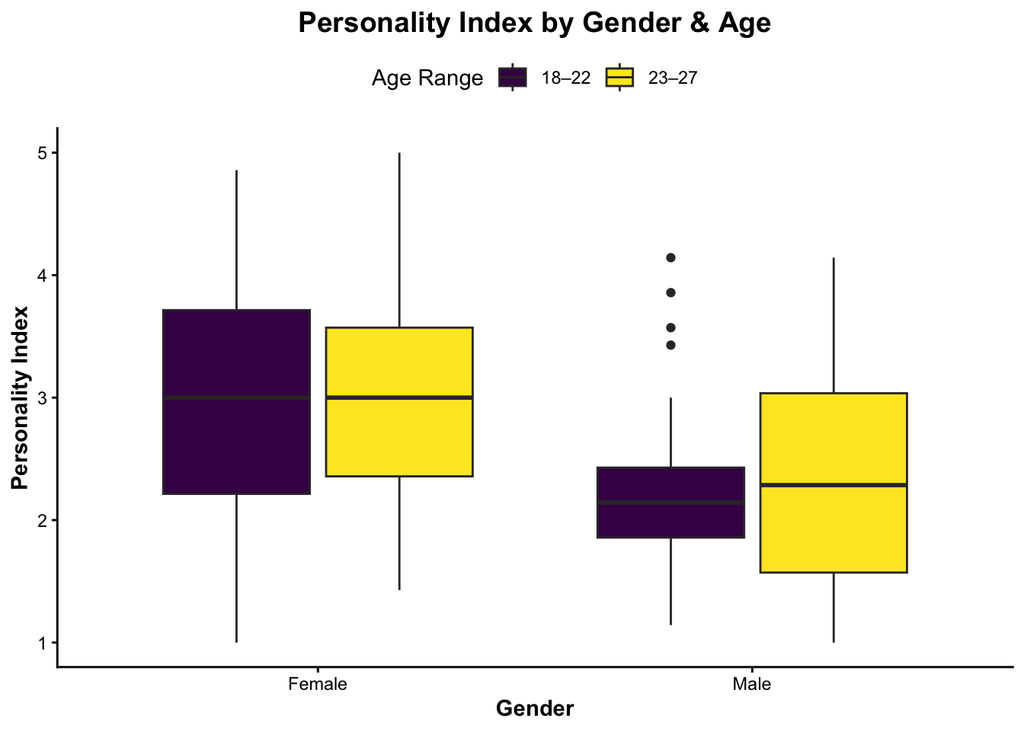

```r
# personality index by gender & age
ggplot(data = df,aes(x = q2, y = personality_index, fill = q1)) +
  geom_boxplot() +
  labs(
    title = "Personality Index by Gender & Age",
    x = "Gender",
    y = "Personality Index",
    fill = "Age Range"
  ) +
  theme_classic() +
  theme(
    plot.title = element_text(hjust = 0.5, face = "bold", size = 14),
    axis.title.x = element_text(face = "bold"),
    axis.title.y = element_text(face = "bold"),
    legend.position = "top"
  )
```

**Key Insights**

Females have a markedly higher median (3.0 at both ages) than males (2.14–2.29)—the largest, most consistent gender gap among the three indices.

### Personality Traits vs. Regret

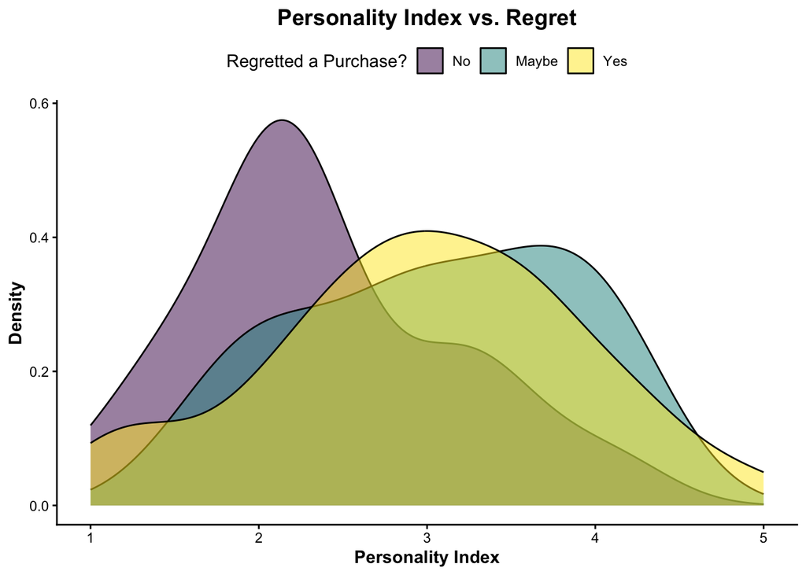

```r
# displaying the relationship between purchase regret and personality index
ggplot(data = df, aes(
  x = personality_index,
  fill = q25_label
  )) +
  geom_density(alpha = 0.5) +
  labs(
    title = "Personality Index vs. Regret",
    x = "Personality Index",
    y = "Density",
    fill = "Regretted a Purchase?"
  ) +
  theme_classic() +
  theme(
    plot.title = element_text(hjust = 0.5, face = "bold", size = 14),
    axis.title.x = element_text(face = "bold"),
    axis.title.y = element_text(face = "bold"),
    legend.position = "top"
  )
```

**Key Insights**

### Personality Traits vs. Unnecessary Purchase

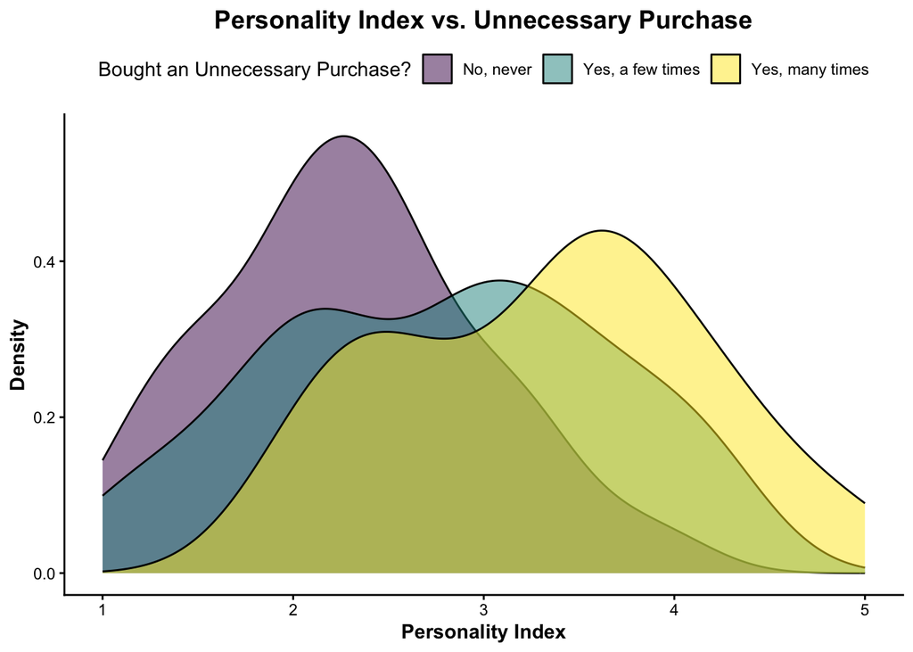

```r
# displaying the relationship between personality influence index and unnecessary purchase
ggplot(data = df, aes(
  x = personality_index,
  fill = q24_label
  )) +
  geom_density(alpha = 0.5) +
  labs(
    title = "Personality Index vs. Unnecessary Purchase",
    x = "Personality Index",
    y = "Density",
    fill = "Bought an Unnecessary Purchase?"
    ) +
  theme_classic() +
  theme(
    plot.title = element_text(hjust = 0.5, face = "bold", size = 14),
    axis.title.x = element_text(face = "bold"),
    axis.title.y = element_text(face = "bold"),
    legend.position = "top"
  )
```

**Key Insights**

- Clearest gradient of all the density plots: mean personality rises 2.29 → 2.76 → 3.34 across **No**/**a few**/**many** unused purchases.
- Suggests higher-personality-index respondents accumulate more unused items—consistent with an impulsivity interpretation.

### Personality Traits vs. Dependent Variable

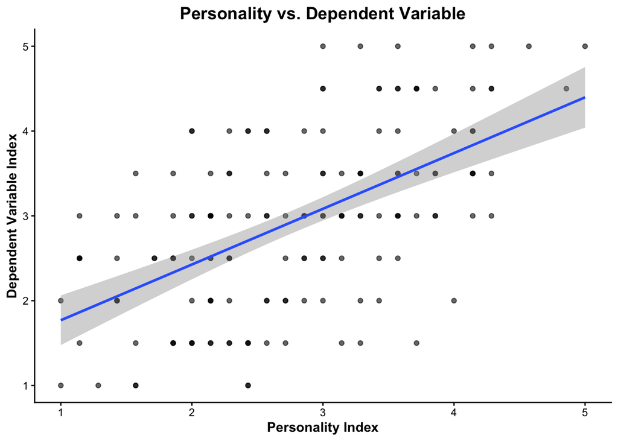

```r
# creating a scatterplot of the personality index and the dependent variable index
ggplot(data = df, aes(x = personality_index, y = dependent_variable_index)) +
  geom_point(alpha = 0.6) +
  geom_smooth(method = "lm") +
  labs(
    title = "Personality vs. Dependent Variable",
    x = "Personality Index",
    y = "Dependent Variable Index"
    ) +
  theme_classic() +
  theme(
    plot.title = element_text(hjust = 0.5, face = "bold", size = 14),
    axis.title.x = element_text(face = "bold"),
    axis.title.y = element_text(face = "bold")
  )
```

**Key Insights**

- Strongest association of any predictor with the DV (r = 0.57).
- The positive slope is visibly tighter than the peer or status scatters, foreshadowing personality as the key predictor in H1/H2.

## Post-Purchase Outcomes & Rationalizations

### How Often Gen Z Make Unplanned Purchases

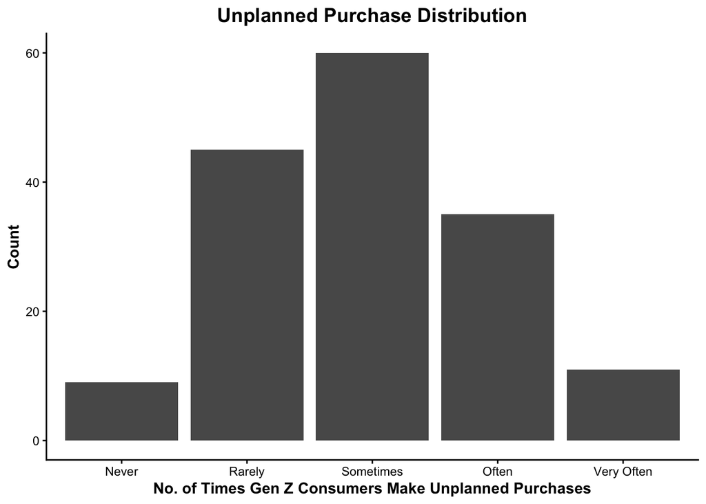

```r
# creating a barchart of how often people make unplanned purchases
ggplot(data = df, aes(
  x = q23_label
  )) +
  geom_bar() +
  labs(
    title = "Unplanned Purchase Distribution",
    x = "No. of Times Gen Z Consumers Make Unplanned Purchases",
    y = "Count"
  ) +
  theme_classic() +
  theme(
    plot.title = element_text(hjust = 0.5, face = "bold", size = 14),
    axis.title.x = element_text(face = "bold"),
    axis.title.y = element_text(face = "bold")
  )
```

**Key Insights**

Centered on **Sometimes** (60) and **Rarely** (45); extremes are uncommon (**Very Often** 11, **Never** 9).

### How Frequently Gen Z Consumers Bought an Item That Were Never Used

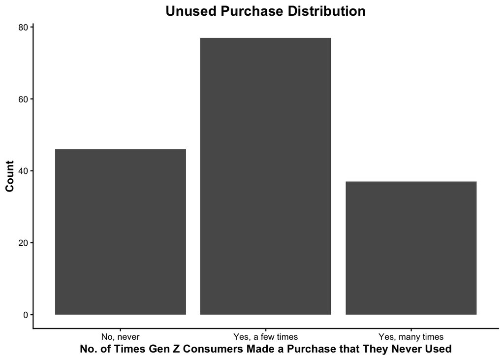

```r
# creating a barchart of how often people bought items they never used
ggplot(data = df, aes(
  x = q24_label
)) +
  geom_bar() +
  labs(
    title = "Unused Purchase Distribution",
    x = "No. of Times Gen Z Consumers Made a Purchase that They Never Used",
    y = "Count"
  ) +
  theme_classic() +
  theme(
    plot.title = element_text(hjust = 0.5, face = "bold", size = 14),
    axis.title.x = element_text(face = "bold"),
    axis.title.y = element_text(face = "bold")
  )
```

**Key Insights**

### How Often Gen Z Consumers Bought an Item That They Regretted

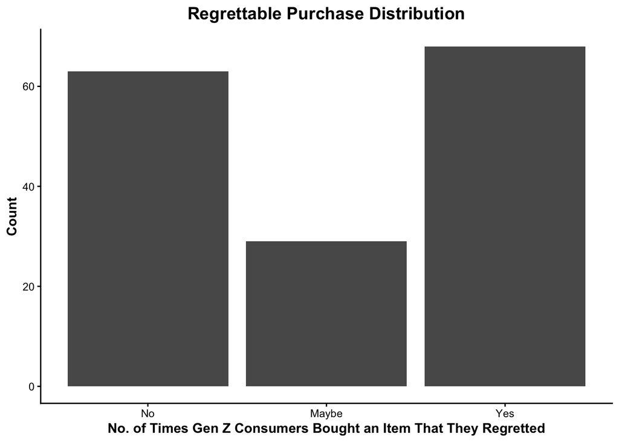

```r
# creating a barchart of how often people regretted a purchase
ggplot(data = df, aes(
  x = q25_label
)) +
  geom_bar() +
  labs(
    title = "Regrettable Purchase Distribution",
    x = "No. of Times Gen Z Consumers Bought an Item That They Regretted",
    y = "Count"
  ) +
  theme_classic() +
  theme(
    plot.title = element_text(hjust = 0.5, face = "bold", size = 14),
    axis.title.x = element_text(face = "bold"),
    axis.title.y = element_text(face = "bold")
  )
```

**Key Insights**

- The distribution is **bimodal/polarized**—63 say **No** and 68 say **Yes**, with only 29 in the middle.
- Respondents tend to fall clearly into **regret** or **no regret** camps rather than the middle—relevant to how you frame H7.

## Payment Mechanics & Financial Access

[figure not shown]

```r
# creating a side-by-side bar chart of the payment methods by income
ggplot(df, aes(x = q3, fill = q4)) +
  geom_bar(position = "dodge") +
  labs(
    title = "Payment Method by Income",
    x = "Personal Monthly Allowance/Income (BDT)",
    y = "Count",
    fill = "Payment Method"
    ) +
  theme_classic() +
  theme(
    plot.title = element_text(hjust = 0.5, face = "bold", size = 14),
    axis.title.x = element_text(face = "bold"),
    axis.title.y = element_text(face = "bold"),
    legend.position = "top"
  )
```

**Key Insights**

## Bringing All the Indices Together

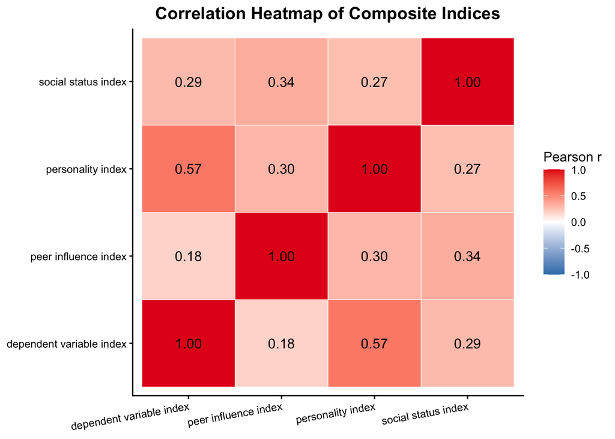

```r
indices <- c(
  "peer_influence_index",
  "social_status_index",
  "personality_index",
  "dependent_variable_index"
  )

cor_long <- df |>
  select(all_of(indices)) |>
  cor(use = "complete.obs") |>
  as_tibble(rownames = "var1") |>
  pivot_longer(-var1, names_to = "var2", values_to = "corr")

ggplot(data = cor_long, aes(x = var1, y = var2, fill = corr)) +
  geom_tile(color = "white") +
  geom_text(aes(label = sprintf("%.2f", corr)), size = 4) +
  scale_fill_gradient2(
    low = "#377EB8",
    mid = "#FFFFFF",
    high = "#E41A1C",
    midpoint = 0,
    limits = c(-1, 1)
    ) +
  scale_x_discrete(labels = function(x) gsub("_", " ", x)) +
  scale_y_discrete(labels = function(x) gsub("_", " ", x)) +
  labs(
    title = "Correlation Heatmap of Composite Indices",
    x = NULL,
    y = NULL,
    fill = "Pearson r"
    ) +
  theme_classic() +
  theme(
    plot.title = element_text(hjust = 0.5, face = "bold", size = 14),
    axis.text.x = element_text(angle = 10, hjust = 1)
    )
```

**Key Insights**

- All four indices are positively correlated (0.18–0.57); no negative relationships.
- Personality ↔︎ DV (0.57) is the standout; peer ↔︎ DV (0.18) the weakest.
- Inter-predictor correlations are low (0.27–0.34), so multicollinearity is unlikely to trouble the H1 regression.

# Hypothesis Testing

For this paper, we have set up **ten** hypotheses which we will now scrutinize using the appropriate statistical tests. **These ten hypotheses are:**

1. Peer Influence, Perceived Social Status, and Behavioral Traits jointly and significantly predict impulsive online fashion buying behavior among Dhaka Gen Z consumers.
2. Specific Behavioral Traits have no significant effect on impulse buying behavior among Dhaka Gen Z consumers.
3. Peer influence has no significant effect on impulsive online fashion buying behavior among Dhaka Gen Z consumers.
4. Perceived social status has no significant effect on impulse buying behavior among Dhaka Gen Z consumers.
5. Peer Influence has no significant effect on perceived social status pressure among Dhaka Gen Z consumers.
6. Impulsive online fashion buying behavior does not differ significantly based on the primary social commerce platform used by Dhaka Gen Z consumers.
7. Higher impulsivity is not significantly associated with post-purchase regrets among Dhaka Gen Z consumers.
8. There is no significant association between preferred payment method and impulsive online fashion buying behavior among Dhaka Gen Z consumers.
9. Dhaka Gen Z consumers with higher monthly personal allowance does not exhibit significantly higher impulsive buying behavior.
10. There is no significant difference in impulsive online fashion buying behavior between male and female Dhaka Gen Z consumers.

## Hypothesis 01

*Peer Influence, Perceived Social Status, and Behavioral Traits jointly and significantly predict impulsive online fashion buying behavior among Dhaka Gen Z consumers.*

This hypothesis aims to find the relationship between the core independent variables (peer influence, perceived social status, personality traits) and impulsive buying. As the independent variables (Peer Influence Index, Social Status Index, and Personality Index) are numeric composite scores and the dependent variable (Impulsive Buying Index) is also a numeric composite score, a **two-tailed multiple linear regression** was conducted to examine whether the null hypothesis can be rejected.

```r
# simple multiple linear regression
model_h1 <- lm(
  formula = dependent_variable_index ~ peer_influence_index + social_status_index + personality_index,
  data = df
  )

summary(model_h1)
```

```
##
## Call:
## lm(formula = dependent_variable_index ~ peer_influence_index +
##     social_status_index + personality_index, data = df)
##
## Residuals:
##      Min       1Q   Median       3Q      Max
## -2.08507 -0.62758  0.01845  0.63899  2.03376
##
## Coefficients:
##                      Estimate Std. Error t value Pr(>|t|)
## (Intercept)           0.80829    0.30789   2.625  0.00952 **
## peer_influence_index -0.03818    0.08689  -0.439  0.66097
## social_status_index   0.18606    0.08442   2.204  0.02899 *
## personality_index     0.62050    0.07923   7.832 6.92e-13 ***
## ---
## Signif. codes:  0 '***' 0.001 '**' 0.01 '*' 0.05 '.' 0.1 ' ' 1
##
## Residual standard error: 0.8461 on 156 degrees of freedom
## Multiple R-squared:  0.3473, Adjusted R-squared:  0.3348
## F-statistic: 27.67 on 3 and 156 DF,  p-value: 2.1e-14
```

The test reveals the p-value to be **less than 0.001**, which is less than or equal to the α (0.05), and the model explains a substantial portion (**34.73%**) of the variance. Holding other variables constant, personality traits (β = **0.621**, p < 0.001) and perceived social status (β = **0.186**, p = 0.029) are both significantly related to the dependent variable, whereas peer influence is not (β = **-0.038**, p = 0.661). So, we can hereby *reject* the null that *peer influence, perceived social status, and personality traits does not jointly and significantly predict impulsive online fashion buying behavior among Dhaka Gen Z consumers*, i.e., and accept the alternative that they do jointly and significantly predict.

## Hypothesis 02

*Specific Behavioral Traits have no significant effect on impulse buying behavior among Dhaka Gen Z consumers.*

This hypothesis aims to find the relationship between behavioral traits (shaped by personality traits) and impulsive buying. As both the independent variable (Personality Traits Index) and dependent variable (Impulsive Buying Index) are numeric composite scores, a **simple linear regression** was performed to determine whether the null can be rejected.

```r
# Linear Regression
model_h2 <- lm(
  formula = dependent_variable_index ~ personality_index,
  data = df
  )

summary(model_h2)
```

```
##
## Call:
## lm(formula = dependent_variable_index ~ personality_index, data = df)
##
## Residuals:
##      Min       1Q   Median       3Q      Max
## -2.05277 -0.64517  0.01046  0.63546  1.91659
##
## Coefficients:
##                   Estimate Std. Error t value Pr(>|t|)
## (Intercept)        1.11209    0.21771   5.108 9.27e-07 ***
## personality_index  0.65711    0.07502   8.759 2.88e-15 ***
## ---
## Signif. codes:  0 '***' 0.001 '**' 0.01 '*' 0.05 '.' 0.1 ' ' 1
##
## Residual standard error: 0.8538 on 158 degrees of freedom
## Multiple R-squared:  0.3269, Adjusted R-squared:  0.3226
## F-statistic: 76.72 on 1 and 158 DF,  p-value: 2.884e-15
```

The test reveals the p-value to be **less than 0.001**, which is less than or equal to the α (0.05), and personality traits now explain a substantial portion (**32.69%**) of the variance in impulsive buying. The relationship is positive (β = **0.657**), meaning stronger personality-driven tendencies are associated with higher, not lower, impulsive buying. So, we can hereby *reject* the null that *specific behavioral traits (shaped by personality traits) have no significant effect on impulse buying behavior among Dhaka Gen Z consumers*, i.e., and accept the alternative that specific behavioral traits have a significant effect on impulse buying.

## Hypothesis 03

*Peer influence has no significant effect on impulsive online fashion buying behavior among Dhaka Gen Z consumers.*

This hypothesis aims to find the relationship between peer influence and impulsive buying. As both the independent variable (Peer Influence Index) and dependent variable (Impulsive Buying Index) are numeric composite scores, a **simple linear regression** was performed to determine whether the null can be rejected.

```r
# simple linear regression
model_h3 <- lm(
  formula = dependent_variable_index ~ peer_influence_index,
  data = df
  )

summary(object = model_h3)
```

```
##
## Call:
## lm(formula = dependent_variable_index ~ peer_influence_index,
##     data = df)
##
## Residuals:
##      Min       1Q   Median       3Q      Max
## -2.20285 -0.75516 -0.06854  0.66650  2.24484
##
## Coefficients:
##                      Estimate Std. Error t value Pr(>|t|)
## (Intercept)           2.26270    0.29602   7.644 1.92e-12 ***
## peer_influence_index  0.22384    0.09624   2.326   0.0213 *
## ---
## Signif. codes:  0 '***' 0.001 '**' 0.01 '*' 0.05 '.' 0.1 ' ' 1
##
## Residual standard error: 1.023 on 158 degrees of freedom
## Multiple R-squared:  0.03311,    Adjusted R-squared:  0.02699
## F-statistic:  5.41 on 1 and 158 DF,  p-value: 0.0213
```

The test reveals the p-value to be **0.021**, which is less than or equal to the α (0.05), though the model still explains only a modest portion (**3.31%**) of the variance. This means peer influence (β = **0.224**) is positively and significantly related to impulsive buying. So, we can hereby *reject* the null that *peer influence has no significant effect on impulsive online fashion buying behavior among Dhaka Gen Z consumers*, i.e., and accept the alternative that peer influence has a significant effect.

## Hypothesis 04

*Perceived social status has no significant effect on impulse buying behavior among Dhaka Gen Z consumers.*

As both the independent variable (Perceived Social Status Index) and dependent variable (Impulsive Buying Index) are numeric composite scores, a **simple linear regression** was performed to determine whether the null can be rejected.

```r
# simple linear regression
model_h4 <- lm(
  formula = dependent_variable_index ~ social_status_index,
  data = df
  )

summary(object = model_h4)
```

```
##
## Call:
## lm(formula = dependent_variable_index ~ social_status_index,
##     data = df)
##
## Residuals:
##      Min       1Q   Median       3Q      Max
## -2.02073 -0.82689 -0.00035  0.65783  2.52004
##
## Coefficients:
##                     Estimate Std. Error t value Pr(>|t|)
## (Intercept)          1.95958    0.26772   7.320 1.19e-11 ***
## social_status_index  0.34692    0.09194   3.773 0.000227 ***
## ---
## Signif. codes:  0 '***' 0.001 '**' 0.01 '*' 0.05 '.' 0.1 ' ' 1
##
## Residual standard error: 0.9967 on 158 degrees of freedom
## Multiple R-squared:  0.08266,    Adjusted R-squared:  0.07686
## F-statistic: 14.24 on 1 and 158 DF,  p-value: 0.0002275
```

The test reveals the p-value to be **less than 0.001**, which is less than or equal to the α (0.05), and the model explains a moderate portion (**8.27%**) of the variance. Perceived social status (β = **0.347**) shows a significant positive relationship with impulsive buying behavior. So, we can hereby *reject* the null that *perceived social status has no significant effect on impulse buying behavior among Dhaka Gen Z consumers*, i.e., and accept the alternative that perceived social status has a significant effect.

## Hypothesis 05

*Peer Influence has no significant effect on perceived social status pressure among Dhaka Gen Z consumers.*

As both the independent variable (Peer Influence Index) and dependent variable (Perceived Social Status Index) are numeric composite scores, a **simple linear regression** was performed to determine whether the null can be rejected.

```r
# linear regression
model_h5 <- lm(
  formula = social_status_index ~ peer_influence_index,
  data = df
  )

summary(model_h5)
```

```
##
## Call:
## lm(formula = social_status_index ~ peer_influence_index, data = df)
##
## Residuals:
##      Min       1Q   Median       3Q      Max
## -1.58947 -0.68939 -0.02027  0.55283  1.92610
##
## Coefficients:
##                      Estimate Std. Error t value Pr(>|t|)
## (Intercept)            1.7590     0.2347   7.495 4.44e-12 ***
## peer_influence_index   0.3460     0.0763   4.535 1.13e-05 ***
## ---
## Signif. codes:  0 '***' 0.001 '**' 0.01 '*' 0.05 '.' 0.1 ' ' 1
##
## Residual standard error: 0.8112 on 158 degrees of freedom
## Multiple R-squared:  0.1152, Adjusted R-squared:  0.1096
## F-statistic: 20.57 on 1 and 158 DF,  p-value: 1.133e-05
```

The test reveals the p-value to be **less than 0.001**, which is less than or equal to the α (0.05). The model explains a modest portion (**11.52%**) of the variance, with peer influence (β = **0.346**) positively predicting perceived social status pressure. So, we can hereby *reject* the null that *peer influence has no significant effect on perceived social status pressure among Dhaka Gen Z consumers*, i.e., and accept the alternative that peer influence has a significant effect.

## Hypothesis 06

*Impulsive online fashion buying behavior does not differ significantly based on the primary social commerce platform used by Dhaka Gen Z consumers.*

This hypothesis aims to find whether impulsive buying differs across the primary platform used for fashion shopping. As the independent variable (Primary Platform Used) is categorical with four groups of highly uneven size (from n = 8 for Daraz to n = 88 for Facebook) and the dependent variable (Impulsive Buying Index) is a numeric composite score, a **Kruskal–Wallis test** (non-parametric, two-tailed) was conducted to examine whether the null hypothesis can be rejected, since ANOVA’s normality assumption becomes unreliable for a group this small. A Kruskal-Wallis test will be used instead of a one-way ANOVA because the smallest group (Daraz, n = 8) makes ANOVA’s normality-within-group assumption unreliable—this non-parametric test doesn’t require that assumption at all.

```r
# converting the platform variable to factor and drop TikTok (0 responses)
df_h6 <- df |>
  mutate(q6 = as.factor(q6)) |>
  filter(q6 != "TikTok")

# running a Kruskal-Wallis test
kruskal.test(
  formula = dependent_variable_index ~ q6,
  data = df_h6
  )
```

```
##
##  Kruskal-Wallis rank sum test
##
## data:  dependent_variable_index by q6
## Kruskal-Wallis chi-squared = 13.955, df = 3, p-value = 0.002966
```

The test reveals the p-value to be **0.003**, which is less than or equal to the α (0.05). This means impulsive online fashion buying behavior does differ significantly based on the primary social commerce platform used, with Instagram users showing the highest average impulsivity and brand-website shoppers the lowest. So, we can hereby *reject* the null that *impulsive online fashion buying behavior does not differ significantly based on the primary social commerce platform used by Dhaka Gen Z consumers*, i.e., and accept the alternative that it does differ significantly.

## Hypothesis 07

*Higher impulsivity is not significantly associated with post-purchase regrets among Dhaka Gen Z consumers.*

This hypothesis aims to find the relationship between impulsivity and post-purchase regret. As the independent variable (Post-Purchase Regret) is categorical and the dependent variable (Impulsive Buying Index) is a numeric composite score, a **one-way ANOVA (two-tailed)** was conducted to test whether the null hypothesis can be rejected.

```r
# running a one-way ANOVA test
anova_h7 <- aov(
  formula = dependent_variable_index ~ q25_label,
  data = df
)

summary(anova_h7)
```

```
##              Df Sum Sq Mean Sq F value   Pr(>F)
## q25_label     2  21.79  10.893   11.45 2.27e-05 ***
## Residuals   157 149.31   0.951
## ---
## Signif. codes:  0 '***' 0.001 '**' 0.01 '*' 0.05 '.' 0.1 ' ' 1
```

The test reveals the p-value to be **less than 0.001**, which is less than or equal to the α (0.05).

We now runn a **post-hoc Tukey HSD** because the ANOVA came back significant—the ANOVA only tells us some group differs from another whereas Tukey tells us specifically which pairs (e.g., is it Yes vs. No, or Maybe vs. No, or both).

```r
# post-hoc Tukey HSD
TukeyHSD(x = anova_h7)
```

```
##   Tukey multiple comparisons of means
##     95% family-wise confidence level
##
## Fit: aov(formula = dependent_variable_index ~ q25_label, data = df)
##
## $q25_label
##                diff         lwr       upr     p adj
## Maybe-No  0.4310345 -0.08677297 0.9488419 0.1231637
## Yes-No    0.8161765  0.41266622 1.2196867 0.0000116
## Yes-Maybe 0.3851420 -0.12662948 0.8969135 0.1794067
```

Only **one** of the three pairwise comparisons clears the 0.05 bar. **Maybe** sits numerically between **No** (2.50) and **Yes** (3.32) at 2.93, but statistically it’s not distinguishable from either neighbor—it just doesn’t have enough separation (or a big enough sample, n = 29) to be confident it’s different from either **No** or **Yes**.

We now check the equal-variance assumption ANOVA relies on (Levene’s test)—if this test itself came back significant, it would mean the group variances differ too much for the ANOVA p-value above to be trustworthy.

```r
# Levene's test
leveneTest(
  y = dependent_variable_index ~ q25_label,
  data = df
)
```

```
## Levene's Test for Homogeneity of Variance (center = median)
##        Df F value Pr(>F)
## group   2  0.2722 0.7621
##       157
```

From the test, p = **0.762**—not significant, meaning there is no evidence that the variances differ. This is good news since it means the ANOVA’s equal-variance assumption holds, so the ANOVA’s p-value can be trusted above rather than needing to lean on the Kruskal-Wallis backup.

Finally, we run an optional non-parametric backup (**Kruskal-Wallis**) as a robustness check—since it makes no assumption about normality or equal variances, agreement between this and the ANOVA above means the conclusion doesn’t hinge on those assumptions holding.

```r
# Kruskal-Wallis test
kruskal.test(
  formula = dependent_variable_index ~ q25_label,
  data = df
)
```

```
##
##  Kruskal-Wallis rank sum test
##
## data:  dependent_variable_index by q25_label
## Kruskal-Wallis chi-squared = 18.753, df = 2, p-value = 8.467e-05
```

χ² = **18.75**, p = **8.47e-05**—also significant, agrees with the ANOVA. Since Levene’s already told us the variances are fine, this backup test is really just extra reassurance, not doing new work—but it’s nice that it agrees.

This tests mean higher impulsivity is significantly associated with post-purchase regret, though the post-hoc comparison shows this is driven specifically by the **Yes** group—respondents who regretted a purchase scored significantly higher on impulsivity than those who said **No** (p < 0.001). The **Maybe** group falls in between numerically but is not statistically distinguishable from either **No** (p = 0.123) or **Yes** (p = 0.179), likely reflecting its smaller sample size (n = 29) as much as genuine ambiguity. So, we can hereby *reject* the null that *higher impulsivity is not significantly associated with post-purchase regrets among Dhaka Gen Z consumers*, i.e., and accept the alternative that higher impulsivity is significantly associated with post-purchase regrets.

## Hypothesis 08

*There is no significant association between preferred payment method and impulsive online fashion buying behavior among Dhaka Gen Z consumers.*

This hypothesis aims to find whether preferred payment method is associated with impulsive buying. As the independent variable (Payment Method) and the dependent variable (Impulsivity Category, derived from the frequency of unplanned purchases in Q23, grouped into Low/Medium/High) are both categorical, a **two-tailed chi-square test of independence** was conducted to examine whether the null hypothesis can be rejected.

First, we categorize q23 into Low/Medium/High since a chi-square test of independence needs two categorical variables, and payment method is already categorical, so the numeric q23 needs bucketing first.

```r
# categorizing q23 into Low/Medium/High
df <- df |>
  mutate(
    q23_cat = case_when(
      q23 %in% c(1, 2) ~ "Low",
      q23 == 3 ~ "Medium",
      q23 %in% c(4, 5) ~ "High",
      TRUE ~ NA_character_
    )
  )
```

Now, we build the contingency table (Payment Method x Impulsivity Category) since this cross-tab of observed counts is the actual input the chi-square test compares against expected counts.

```r
# building the contingency table (Payment Method x Impulsivity Category)—this cross-tab of observed counts is the actual input the chi-square test compares against expected counts
tab_h8 <- table(df$q4, df$q23_cat)

# viewing the table
tab_h8
```

```
##
##                                                  High Low Medium
##   Cash on Delivery (COD)                           26  30     31
##   Credit/debit card                                 5   5      4
##   Mobile financial services (bKash/Nagad/Rocket)   15  19     25
```

We run the chi-square test with a Monte Carlo simulation (`simulate.p.value = TRUE`) instead of the standard asymptotic p-value, because several cells above have small expected counts—the usual chi-square approximation isn’t reliable when expected counts drop much below 5.

```r
# running a Chi-square test of independence
chisq_result <- chisq.test(
  x = tab_h8,
  simulate.p.value = TRUE,
  B = 10000
)

chisq_result
```

```
##
##  Pearson's Chi-squared test with simulated p-value (based on 10000
##  replicates)
##
## data:  tab_h8
## X-squared = 1.326, df = NA, p-value = 0.8655
```

```r
# checking the expected cell counts
chisq_result$expected
```

```
##
##                                                     High     Low Medium
##   Cash on Delivery (COD)                         25.0125 29.3625 32.625
##   Credit/debit card                               4.0250  4.7250  5.250
##   Mobile financial services (bKash/Nagad/Rocket) 16.9625 19.9125 22.125
```

## Hypothesis 09

*Dhaka Gen Z consumers with higher monthly personal allowance does not exhibit significantly higher impulsive buying behavior.*

As the independent variable (Monthly Income/Allowance) is categorical and the dependent variable (Impulsivity) is a numeric composite score, a **one-way ANOVA (two-tailed)** was conducted to test whether the null hypothesis can be rejected.

```r
# running a one-way ANOVA test
anova_h9 <- aov(
  formula = dependent_variable_index ~ q3,
  data = df
)

summary(anova_h9)
```

```
##              Df Sum Sq Mean Sq F value  Pr(>F)
## q3            4   15.1   3.775   3.751 0.00609 **
## Residuals   155  156.0   1.006
## ---
## Signif. codes:  0 '***' 0.001 '**' 0.01 '*' 0.05 '.' 0.1 ' ' 1
```

The test reveals the p-value to be **0.006**, which is less than or equal to the α (0.05).

```r
# running a Post-hoc (as the ANOVA is significant) to see which group differs
TukeyHSD(x = anova_h9)
```

```
##   Tukey multiple comparisons of means
##     95% family-wise confidence level
##
## Fit: aov(formula = dependent_variable_index ~ q3, data = df)
##
## $q3
##                                    diff         lwr       upr     p adj
## 5,000–10,000-Below 5,000     0.29304029 -0.39794874 0.9840293 0.7681330
## 10,000–15,000-Below 5,000    0.70238095  0.02680625 1.3779557 0.0372115
## 15,000–20,000-Below 5,000    0.79880952  0.04652138 1.5510977 0.0313855
## Above 20,000-Below 5,000     0.64880952  0.05146311 1.2461559 0.0259263
## 10,000–15,000-5,000–10,000   0.40934066 -0.34481190 1.1634932 0.5652421
## 15,000–20,000-5,000–10,000   0.50576923 -0.31780976 1.3293482 0.4400225
## Above 20,000-5,000–10,000    0.35576923 -0.32918890 1.0407274 0.6069740
## 15,000–20,000-10,000–15,000  0.09642857 -0.71426107 0.9071182 0.9974673
## Above 20,000-10,000–15,000  -0.05357143 -0.72297637 0.6158335 0.9994662
## Above 20,000-15,000–20,000  -0.15000000 -0.89675247 0.5967525 0.9812482
```

```r
# doing an assumption check (variance equality)
leveneTest(
  y = dependent_variable_index ~ q3,
  data = df
)
```

```
## Levene's Test for Homogeneity of Variance (center = median)
##        Df F value Pr(>F)
## group   4  1.1028 0.3573
##       155
```

From the test, p = **0.357**—not significant, meaning there is no evidence that the variances differ. This is good news since it means the ANOVA’s equal-variance assumption holds, so the ANOVA’s p-value can be trusted above rather than needing to lean on the Kruskal-Wallis backup.

```r
# conducting a Non-parametric backup (optional)
kruskal.test(
  formula = dependent_variable_index ~ q3,
  data = df
  )
```

```
##
##  Kruskal-Wallis rank sum test
##
## data:  dependent_variable_index by q3
## Kruskal-Wallis chi-squared = 14.345, df = 4, p-value = 0.006271
```

From the test, χ² = **14.345**, df = **4**, p = **0.00627**—also significant, agrees with the ANOVA, consistent with Levene’s giving the ANOVA a clean bill of health.

This means Dhaka Gen Z consumers with higher monthly personal allowance do exhibit significantly higher impulsive buying behavior, with post-hoc comparisons confirming that the lowest income group (Below 5,000) differs significantly from every band above 10,000. So, we can hereby *reject* the null that *Dhaka Gen Z consumers with higher monthly personal allowance does not exhibit significantly higher impulsive buying behavior*, i.e., and accept the alternative that they do.

## Hypothesis 10

*There is no significant difference in impulsive online fashion buying behavior between male and female Dhaka Gen Z consumers.*

As the independent variable (Gender) is categorical and the dependent variable (Impulsive Buying Index) is a numeric composite score, a **two-tailed independent-samples t-test (Welch’s t-test)** was conducted to examine whether the null hypothesis can be rejected. We run Welch’s t-test since it doesn’t assume equal variances between groups—a safer default here given the uneven group sizes (63 males vs. 97 females).

We convert gender into a two-level factor since a t-test compares exactly two groups. So this just locks in which two and their order (Male first, Female second).

```r
# correcting the order of q2
df_h10 <- df |>
  mutate(q2 = factor(q2, levels = c("Male", "Female")))

# running the t-test
t.test(
  formula = dependent_variable_index ~ q2,
  data = df_h10
)
```

```
##
##  Welch Two Sample t-test
##
## data:  dependent_variable_index by q2
## t = -4.7907, df = 132.84, p-value = 4.378e-06
## alternative hypothesis: true difference in means between group Male and group Female is not equal to 0
## 95 percent confidence interval:
##  -1.0644575 -0.4423336
## sample estimates:
##   mean in group Male mean in group Female
##             2.468254             3.221649
```

The test reveals the p-value to be **less than 0.001**, which is less than or equal to the α (0.05). This means there is a significant difference in impulsive online fashion buying behavior between male and female Dhaka Gen Z consumers—with female respondents (M = **3.22**) now showing significantly higher impulsivity than male respondents (M = **2.47**). So, we can hereby *reject* the null that *there is no significant difference in impulsive online fashion buying behavior between male and female Dhaka Gen Z consumers*, i.e., and accept the alternative that there is a significant difference.

# Summary & Conclusions

## Summary Table

A summary table of all the ten hypotheses are presented below:

**Table 01:** Summary of Hypothesis Testing Results.

| No. | Hypothesis | Result |
| --- | --- | --- |
| **01** | Peer Influence, Perceived Social Status, and Behavioral Traits jointly and significantly predict impulsive online fashion buying behavior among Dhaka Gen Z consumers. | Reject Null |
| **02** | Specific Behavioral Traits have no significant effect on impulse buying behavior among Dhaka Gen Z consumers. | Reject Null |
| **03** | Peer influence has no significant effect on impulsive online fashion buying behavior among Dhaka Gen Z consumers. | Reject Null |
| **04** | Perceived social status has no significant effect on impulse buying behavior among Dhaka Gen Z consumers. | Reject Null |
| **05** | Peer Influence has no significant effect on perceived social status pressure among Dhaka Gen Z consumers. | Reject Null |
| **06** | Impulsive online fashion buying behavior does not differ significantly based on the primary social commerce platform used by Dhaka Gen Z consumers. | Reject Null |
| **07** | Higher impulsivity is not significantly associated with post-purchase regrets among Dhaka Gen Z consumers. | Reject Null |
| **08** | There is no significant association between preferred payment method and impulsive online fashion buying behavior among Dhaka Gen Z consumers. | Cannot Reject Null |
| **09** | Dhaka Gen Z consumers with higher monthly personal allowance does not exhibit significantly higher impulsive buying behavior. | Reject Null |
| **10** | There is no significant difference in impulsive online fashion buying behavior between male and female Dhaka Gen Z consumers. | Reject Null |

## Conclusion

This study concludes that impulsive fashion buying among Dhaka’s Gen Z is driven primarily by internal psychological states rather than external mechanics. The findings reveal that while peer influence indirectly creates social status pressure, the actual decision to purchase is fueled by internal traits and the desire for emotional gratification. Furthermore, the prevalence of post-purchase regret highlights that impulsive consumption is largely a cyclical process of mood regulation that often conflicts with rational financial behavior.